# Notes FSML II

Tobías Chavarría

DSTI | DSBD2-001

## Introduction

Statistics notation:

1. If $X_1, ..., X_n$ are random variables (r.v).
2. $x_1, ..., x_n$ are observations.
3. If we write *i.i.d* means that the r.v are independent and identically distributed.

**First aim:** To propose a model for a random variable.

Generalization to multi-dimensional case:

- Y: response variable.
- $X^{(1)}, ...,X^{(p)}$: explanatory variables.

**Aim**: To find a functional link between $Y$ and the explanatory variables.

To find this functional link , the method to apply depends on the nature of the r.v’s.

| Y | Model |
| --- | --- |
| Numeric | Linear model |
| Qualitative (labels) | Classification |

**Linear model**

A linear model is given by:

$Y_i = \beta_0 + \beta_1X^{1}_i + ... + \beta_pX^{p}_i + \varepsilon_i$

where:

- $\beta_0, ..., \beta_p$ are unknown *fixed* parameters that can be estimated by two methods:
  - Point estimation
  - Confidence interval
- $\varepsilon$ is the noise and also a random variable.

## Chapter 1: Estimation for **one parameter**

**Previous Knowledge**

- Random Variable:
- The notion of distribution.
- The expectation and variance
- The distribution function
- The classical distributions (in particular the Gaussian)
- The Law of Large numbers and the Central Limit theorem

### Introduction

Given $x_1, ..., x_n$ numeric observations, to try to find a correct parametric model, we can use 2 [graphs](https://chartio.com/learn/charts/histogram-complete-guide/):

- Barplot for discrete variables.

density = count/n

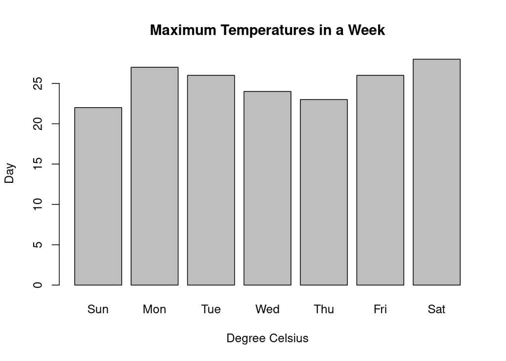

```r
max.temp <- c(22, 27, 26, 24, 23, 26, 28)

barplot(max.temp,
main = "Maximum Temperatures in a Week",
xlab = "Degree Celsius",
ylab = "Day",
names.arg = c("Sun", "Mon", "Tue", "Wed", "Thu", "Fri", "Sat"))
```

- Histogram for continuous variables

density = count for a bin/ n x length of the bin

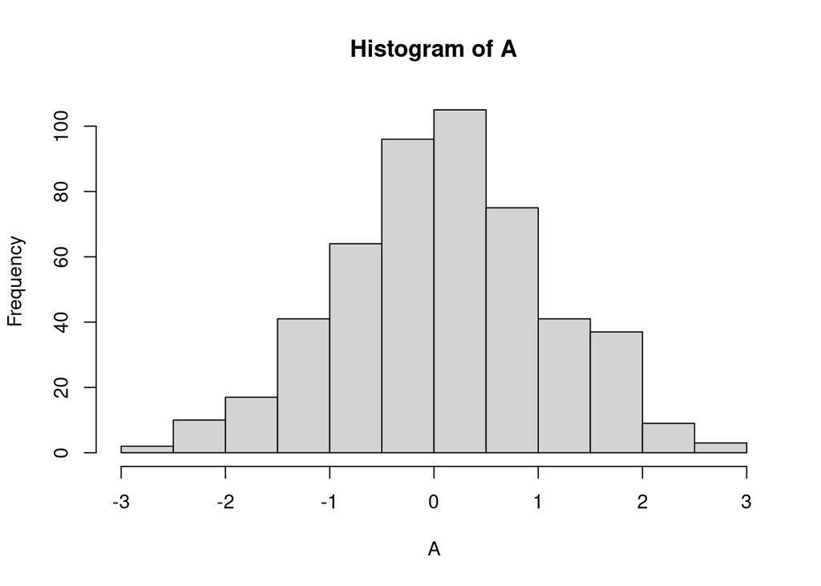

```r
A <- rnorm(500, 0, 1)

hist(A)
```

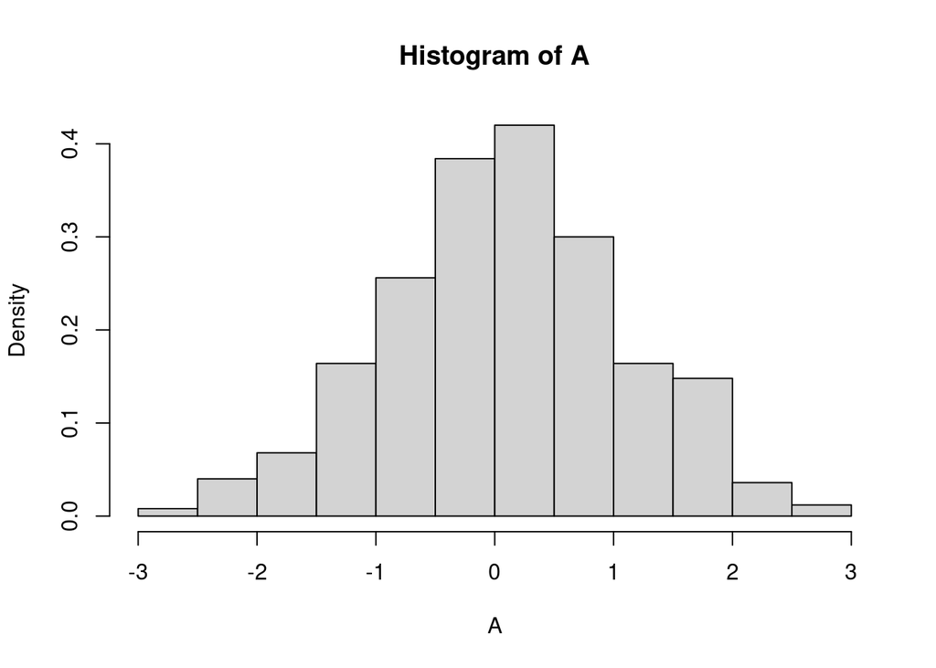

```r
hist(A, freq = FALSE)

hist(A, freq = FALSE, breaks = 20)
```

[output not shown]

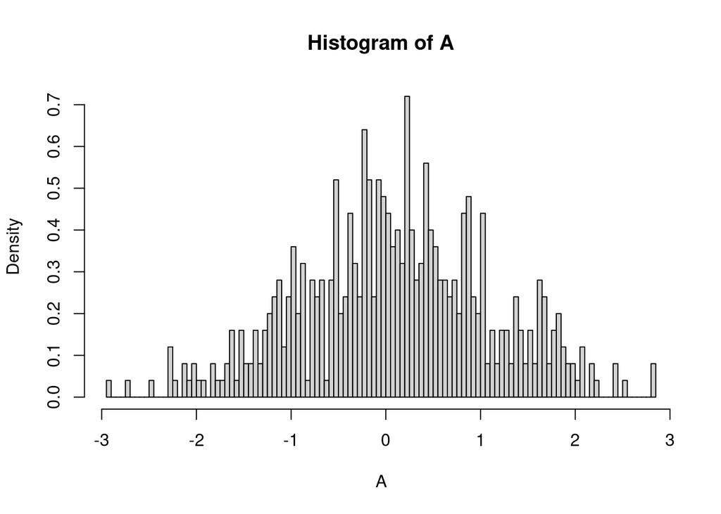

```r
hist(A, freq = FALSE, breaks = 100)
```

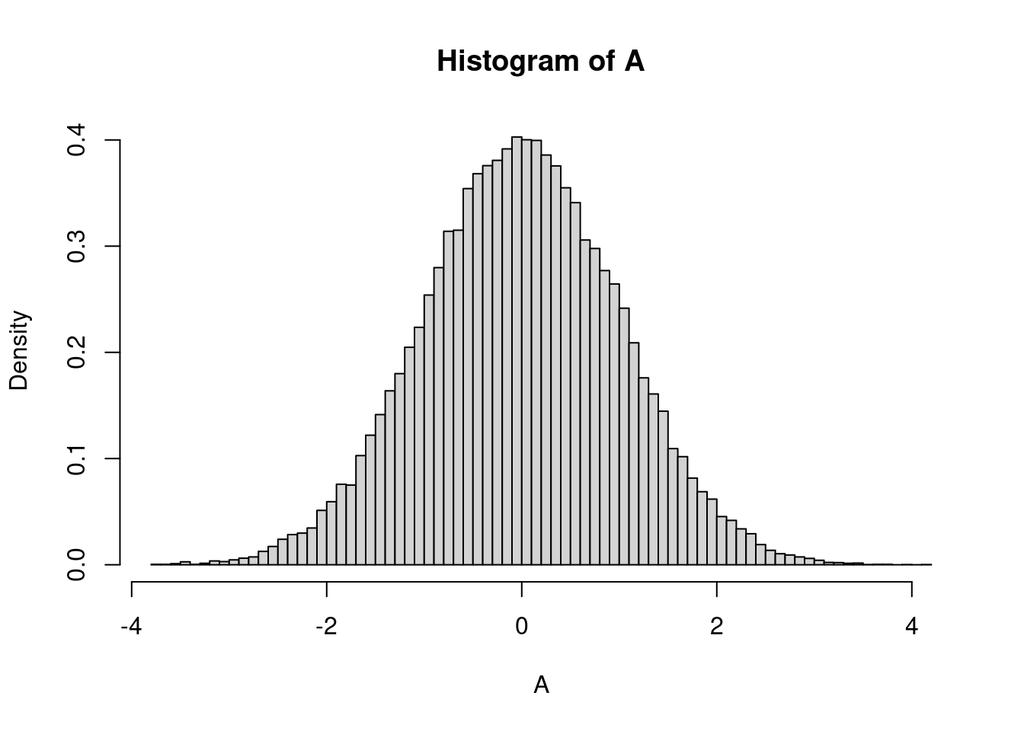

```r
# In order to create more breaks, you need to increase the
# numbers of observations


A <- rnorm(50000, 0, 1)
hist(A, freq = FALSE, breaks = 100)
```

To propose a parametric model:

1. We make a graphical representation of the observations.
2. We guess a theoretical model by looking the previous graphic.

**Question:** with a representation, we can guess a parametric family of models, denoted by $\{P_{\Theta}, \theta \in \Theta \}$. How to guess a correct value for $\theta$ thanks to the observations?

**Answer:** *Estimation*.